# Risk Factor Analysis

## Outcome Variable

**Outcome Variable:** ever_swasted

## Predictor Variables

**Intervention Variable:** perdiar6

**Adjustment Set:**

unadjusted

## Stratifying Variables

The analysis was stratified on these variable(s):

- agecat
- studyid
- country

## Data Summary

| agecat | studyid | country | perdiar6 | ever_swasted | n_cell | n |
| --- | --- | --- | --- | --- | --- | --- |
| 0-24 months (no birth wast) | ki0047075b-MAL-ED | BANGLADESH | (0%, 5%] | 0 | 93 | 261 |
| 0-24 months (no birth wast) | ki0047075b-MAL-ED | BANGLADESH | (0%, 5%] | 1 | 5 | 261 |
| 0-24 months (no birth wast) | ki0047075b-MAL-ED | BANGLADESH | 0% | 0 | 78 | 261 |
| 0-24 months (no birth wast) | ki0047075b-MAL-ED | BANGLADESH | 0% | 1 | 5 | 261 |
| 0-24 months (no birth wast) | ki0047075b-MAL-ED | BANGLADESH | >5% | 0 | 78 | 261 |
| 0-24 months (no birth wast) | ki0047075b-MAL-ED | BANGLADESH | >5% | 1 | 2 | 261 |
| 0-24 months (no birth wast) | ki0047075b-MAL-ED | BRAZIL | (0%, 5%] | 0 | 15 | 229 |
| 0-24 months (no birth wast) | ki0047075b-MAL-ED | BRAZIL | (0%, 5%] | 1 | 0 | 229 |
| 0-24 months (no birth wast) | ki0047075b-MAL-ED | BRAZIL | 0% | 0 | 209 | 229 |
| 0-24 months (no birth wast) | ki0047075b-MAL-ED | BRAZIL | 0% | 1 | 3 | 229 |
| 0-24 months (no birth wast) | ki0047075b-MAL-ED | BRAZIL | >5% | 0 | 2 | 229 |
| 0-24 months (no birth wast) | ki0047075b-MAL-ED | BRAZIL | >5% | 1 | 0 | 229 |
| 0-24 months (no birth wast) | ki0047075b-MAL-ED | INDIA | (0%, 5%] | 0 | 125 | 242 |
| 0-24 months (no birth wast) | ki0047075b-MAL-ED | INDIA | (0%, 5%] | 1 | 3 | 242 |
| 0-24 months (no birth wast) | ki0047075b-MAL-ED | INDIA | 0% | 0 | 51 | 242 |
| 0-24 months (no birth wast) | ki0047075b-MAL-ED | INDIA | 0% | 1 | 4 | 242 |
| 0-24 months (no birth wast) | ki0047075b-MAL-ED | INDIA | >5% | 0 | 56 | 242 |
| 0-24 months (no birth wast) | ki0047075b-MAL-ED | INDIA | >5% | 1 | 3 | 242 |
| 0-24 months (no birth wast) | ki0047075b-MAL-ED | NEPAL | (0%, 5%] | 0 | 75 | 238 |
| 0-24 months (no birth wast) | ki0047075b-MAL-ED | NEPAL | (0%, 5%] | 1 | 1 | 238 |
| 0-24 months (no birth wast) | ki0047075b-MAL-ED | NEPAL | 0% | 0 | 80 | 238 |
| 0-24 months (no birth wast) | ki0047075b-MAL-ED | NEPAL | 0% | 1 | 2 | 238 |
| 0-24 months (no birth wast) | ki0047075b-MAL-ED | NEPAL | >5% | 0 | 80 | 238 |
| 0-24 months (no birth wast) | ki0047075b-MAL-ED | NEPAL | >5% | 1 | 0 | 238 |
| 0-24 months (no birth wast) | ki0047075b-MAL-ED | PERU | (0%, 5%] | 0 | 92 | 299 |
| 0-24 months (no birth wast) | ki0047075b-MAL-ED | PERU | (0%, 5%] | 1 | 1 | 299 |
| 0-24 months (no birth wast) | ki0047075b-MAL-ED | PERU | 0% | 0 | 85 | 299 |
| 0-24 months (no birth wast) | ki0047075b-MAL-ED | PERU | 0% | 1 | 1 | 299 |
| 0-24 months (no birth wast) | ki0047075b-MAL-ED | PERU | >5% | 0 | 119 | 299 |
| 0-24 months (no birth wast) | ki0047075b-MAL-ED | PERU | >5% | 1 | 1 | 299 |

[output cut: 258 more lines]

The following strata were considered:

- agecat: 0-24 months (no birth wast), studyid: ki0047075b-MAL-ED, country: BANGLADESH
- agecat: 0-24 months (no birth wast), studyid: ki0047075b-MAL-ED, country: BRAZIL
- agecat: 0-24 months (no birth wast), studyid: ki0047075b-MAL-ED, country: INDIA
- agecat: 0-24 months (no birth wast), studyid: ki0047075b-MAL-ED, country: NEPAL
- agecat: 0-24 months (no birth wast), studyid: ki0047075b-MAL-ED, country: PERU
- agecat: 0-24 months (no birth wast), studyid: ki0047075b-MAL-ED, country: SOUTH AFRICA
- agecat: 0-24 months (no birth wast), studyid: ki0047075b-MAL-ED, country: TANZANIA, UNITED REPUBLIC OF
- agecat: 0-24 months (no birth wast), studyid: ki1000109-ResPak, country: PAKISTAN
- agecat: 0-24 months (no birth wast), studyid: ki1017093-NIH-Birth, country: BANGLADESH
- agecat: 0-24 months (no birth wast), studyid: ki1017093b-PROVIDE, country: BANGLADESH
- agecat: 0-24 months (no birth wast), studyid: ki1017093c-NIH-Crypto, country: BANGLADESH
- agecat: 0-24 months (no birth wast), studyid: ki1114097-CMIN, country: BANGLADESH
- agecat: 0-24 months (no birth wast), studyid: ki1114097-CMIN, country: BRAZIL
- agecat: 0-24 months (no birth wast), studyid: ki1114097-CMIN, country: GUINEA-BISSAU
- agecat: 0-24 months (no birth wast), studyid: ki1114097-CMIN, country: PERU
- agecat: 0-24 months (no birth wast), studyid: ki1114097-CONTENT, country: PERU
- agecat: 0-6 months (no birth wast), studyid: ki0047075b-MAL-ED, country: BANGLADESH
- agecat: 0-6 months (no birth wast), studyid: ki0047075b-MAL-ED, country: BRAZIL
- agecat: 0-6 months (no birth wast), studyid: ki0047075b-MAL-ED, country: INDIA
- agecat: 0-6 months (no birth wast), studyid: ki0047075b-MAL-ED, country: NEPAL
- agecat: 0-6 months (no birth wast), studyid: ki0047075b-MAL-ED, country: PERU
- agecat: 0-6 months (no birth wast), studyid: ki0047075b-MAL-ED, country: SOUTH AFRICA
- agecat: 0-6 months (no birth wast), studyid: ki0047075b-MAL-ED, country: TANZANIA, UNITED REPUBLIC OF
- agecat: 0-6 months (no birth wast), studyid: ki1000109-ResPak, country: PAKISTAN
- agecat: 0-6 months (no birth wast), studyid: ki1017093-NIH-Birth, country: BANGLADESH
- agecat: 0-6 months (no birth wast), studyid: ki1017093b-PROVIDE, country: BANGLADESH
- agecat: 0-6 months (no birth wast), studyid: ki1017093c-NIH-Crypto, country: BANGLADESH
- agecat: 0-6 months (no birth wast), studyid: ki1114097-CMIN, country: BANGLADESH
- agecat: 0-6 months (no birth wast), studyid: ki1114097-CMIN, country: BRAZIL
- agecat: 0-6 months (no birth wast), studyid: ki1114097-CMIN, country: GUINEA-BISSAU
- agecat: 0-6 months (no birth wast), studyid: ki1114097-CMIN, country: PERU
- agecat: 0-6 months (no birth wast), studyid: ki1114097-CONTENT, country: PERU
- agecat: 6-24 months, studyid: ki0047075b-MAL-ED, country: BANGLADESH
- agecat: 6-24 months, studyid: ki0047075b-MAL-ED, country: BRAZIL
- agecat: 6-24 months, studyid: ki0047075b-MAL-ED, country: INDIA
- agecat: 6-24 months, studyid: ki0047075b-MAL-ED, country: NEPAL
- agecat: 6-24 months, studyid: ki0047075b-MAL-ED, country: PERU
- agecat: 6-24 months, studyid: ki0047075b-MAL-ED, country: SOUTH AFRICA
- agecat: 6-24 months, studyid: ki0047075b-MAL-ED, country: TANZANIA, UNITED REPUBLIC OF
- agecat: 6-24 months, studyid: ki1000109-ResPak, country: PAKISTAN
- agecat: 6-24 months, studyid: ki1017093-NIH-Birth, country: BANGLADESH
- agecat: 6-24 months, studyid: ki1017093b-PROVIDE, country: BANGLADESH
- agecat: 6-24 months, studyid: ki1017093c-NIH-Crypto, country: BANGLADESH
- agecat: 6-24 months, studyid: ki1114097-CMIN, country: BANGLADESH
- agecat: 6-24 months, studyid: ki1114097-CMIN, country: BRAZIL
- agecat: 6-24 months, studyid: ki1114097-CMIN, country: GUINEA-BISSAU
- agecat: 6-24 months, studyid: ki1114097-CMIN, country: PERU
- agecat: 6-24 months, studyid: ki1114097-CONTENT, country: PERU

### Dropped Strata

Some strata were dropped due to rare outcomes:

- agecat: 0-24 months (no birth wast), studyid: ki0047075b-MAL-ED, country: BANGLADESH
- agecat: 0-24 months (no birth wast), studyid: ki0047075b-MAL-ED, country: BRAZIL
- agecat: 0-24 months (no birth wast), studyid: ki0047075b-MAL-ED, country: INDIA
- agecat: 0-24 months (no birth wast), studyid: ki0047075b-MAL-ED, country: NEPAL
- agecat: 0-24 months (no birth wast), studyid: ki0047075b-MAL-ED, country: PERU
- agecat: 0-24 months (no birth wast), studyid: ki0047075b-MAL-ED, country: SOUTH AFRICA
- agecat: 0-24 months (no birth wast), studyid: ki0047075b-MAL-ED, country: TANZANIA, UNITED REPUBLIC OF
- agecat: 0-24 months (no birth wast), studyid: ki1017093b-PROVIDE, country: BANGLADESH
- agecat: 0-24 months (no birth wast), studyid: ki1017093c-NIH-Crypto, country: BANGLADESH
- agecat: 0-24 months (no birth wast), studyid: ki1114097-CMIN, country: BRAZIL
- agecat: 0-24 months (no birth wast), studyid: ki1114097-CMIN, country: PERU
- agecat: 0-24 months (no birth wast), studyid: ki1114097-CONTENT, country: PERU
- agecat: 0-6 months (no birth wast), studyid: ki0047075b-MAL-ED, country: BANGLADESH
- agecat: 0-6 months (no birth wast), studyid: ki0047075b-MAL-ED, country: BRAZIL
- agecat: 0-6 months (no birth wast), studyid: ki0047075b-MAL-ED, country: INDIA
- agecat: 0-6 months (no birth wast), studyid: ki0047075b-MAL-ED, country: NEPAL
- agecat: 0-6 months (no birth wast), studyid: ki0047075b-MAL-ED, country: PERU
- agecat: 0-6 months (no birth wast), studyid: ki0047075b-MAL-ED, country: SOUTH AFRICA
- agecat: 0-6 months (no birth wast), studyid: ki0047075b-MAL-ED, country: TANZANIA, UNITED REPUBLIC OF
- agecat: 0-6 months (no birth wast), studyid: ki1000109-ResPak, country: PAKISTAN
- agecat: 0-6 months (no birth wast), studyid: ki1017093-NIH-Birth, country: BANGLADESH
- agecat: 0-6 months (no birth wast), studyid: ki1017093b-PROVIDE, country: BANGLADESH
- agecat: 0-6 months (no birth wast), studyid: ki1017093c-NIH-Crypto, country: BANGLADESH
- agecat: 0-6 months (no birth wast), studyid: ki1114097-CMIN, country: BANGLADESH
- agecat: 0-6 months (no birth wast), studyid: ki1114097-CMIN, country: BRAZIL
- agecat: 0-6 months (no birth wast), studyid: ki1114097-CMIN, country: GUINEA-BISSAU
- agecat: 0-6 months (no birth wast), studyid: ki1114097-CMIN, country: PERU
- agecat: 0-6 months (no birth wast), studyid: ki1114097-CONTENT, country: PERU
- agecat: 6-24 months, studyid: ki0047075b-MAL-ED, country: BANGLADESH
- agecat: 6-24 months, studyid: ki0047075b-MAL-ED, country: BRAZIL
- agecat: 6-24 months, studyid: ki0047075b-MAL-ED, country: INDIA
- agecat: 6-24 months, studyid: ki0047075b-MAL-ED, country: NEPAL
- agecat: 6-24 months, studyid: ki0047075b-MAL-ED, country: PERU
- agecat: 6-24 months, studyid: ki0047075b-MAL-ED, country: SOUTH AFRICA
- agecat: 6-24 months, studyid: ki0047075b-MAL-ED, country: TANZANIA, UNITED REPUBLIC OF
- agecat: 6-24 months, studyid: ki1017093b-PROVIDE, country: BANGLADESH
- agecat: 6-24 months, studyid: ki1017093c-NIH-Crypto, country: BANGLADESH
- agecat: 6-24 months, studyid: ki1114097-CMIN, country: BRAZIL
- agecat: 6-24 months, studyid: ki1114097-CMIN, country: PERU
- agecat: 6-24 months, studyid: ki1114097-CONTENT, country: PERU

## Methods Detail

We’re interested in the causal parameters $E[Y_a]$ for all values of $a \in \mathcal{A}$. These parameters represent the mean outcome if, possibly contrary to fact, we intervened to set all units to have $A=a$. Under the randomization and positivity assumptions, these are identified by the statistical parameters $\psi_a=E_W[E_{Y|A,W}(Y|A=a,W)]$. In addition, we’re interested in the mean of $Y$, $E[Y]$ under no intervention (the observed mean). We will estimate these parameters by using SuperLearner to fit the relevant likelihood factors – $E_{Y|A,W}(Y|A=a,W)$ and $p(A=a|W)$, and then updating our likelihood fit using a joint TMLE.

For unadjusted analyses ($W=\{\}$), initial likelihoods were estimated using Lrnr_glm to estimate the simple $E(Y|A)$ and Lrnr_mean to estimate $p(A)$. For adjusted analyses, a small library containing Lrnr_glmnet, Lrnr_xgboost, and Lrnr_mean was used.

Having estimated these parameters, we will then use the delta method to estimate relative risks and attributable risks relative to a prespecified baseline level of $A$.

# Results Detail

## Results Plots

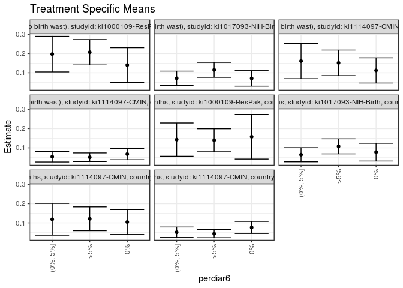

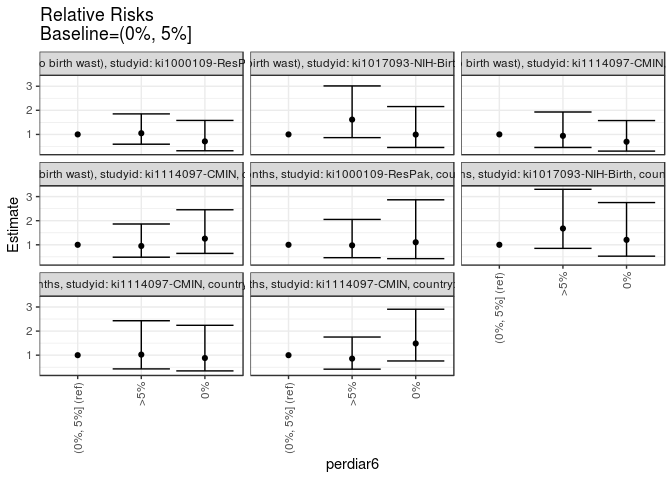

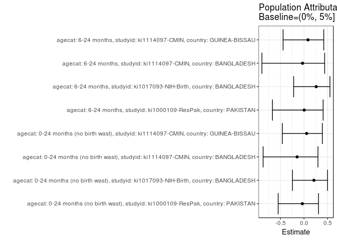

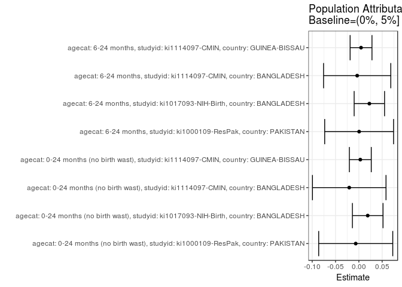

## Results Table

### Parameter: TSM

| agecat | studyid | country | intervention_level | baseline_level | estimate | ci_lower | ci_upper |
| --- | --- | --- | --- | --- | --- | --- | --- |
| 0-24 months (no birth wast) | ki1000109-ResPak | PAKISTAN | (0%, 5%] | NA | 0.1971831 | 0.1044662 | 0.2899000 |
| 0-24 months (no birth wast) | ki1000109-ResPak | PAKISTAN | 0% | NA | 0.1403509 | 0.0500118 | 0.2306900 |
| 0-24 months (no birth wast) | ki1000109-ResPak | PAKISTAN | >5% | NA | 0.2068966 | 0.1408420 | 0.2729511 |
| 0-24 months (no birth wast) | ki1017093-NIH-Birth | BANGLADESH | (0%, 5%] | NA | 0.0714286 | 0.0339813 | 0.1088758 |
| 0-24 months (no birth wast) | ki1017093-NIH-Birth | BANGLADESH | 0% | NA | 0.0709677 | 0.0305109 | 0.1114246 |
| 0-24 months (no birth wast) | ki1017093-NIH-Birth | BANGLADESH | >5% | NA | 0.1153846 | 0.0765180 | 0.1542512 |
| 0-24 months (no birth wast) | ki1114097-CMIN | BANGLADESH | (0%, 5%] | NA | 0.1612903 | 0.0695650 | 0.2530157 |
| 0-24 months (no birth wast) | ki1114097-CMIN | BANGLADESH | 0% | NA | 0.1123596 | 0.0466235 | 0.1780956 |
| 0-24 months (no birth wast) | ki1114097-CMIN | BANGLADESH | >5% | NA | 0.1517857 | 0.0852071 | 0.2183643 |
| 0-24 months (no birth wast) | ki1114097-CMIN | GUINEA-BISSAU | (0%, 5%] | NA | 0.0538462 | 0.0263952 | 0.0812971 |
| 0-24 months (no birth wast) | ki1114097-CMIN | GUINEA-BISSAU | 0% | NA | 0.0676157 | 0.0382423 | 0.0969891 |
| 0-24 months (no birth wast) | ki1114097-CMIN | GUINEA-BISSAU | >5% | NA | 0.0512129 | 0.0287703 | 0.0736556 |
| 6-24 months | ki1000109-ResPak | PAKISTAN | (0%, 5%] | NA | 0.1428571 | 0.0562604 | 0.2294539 |
| 6-24 months | ki1000109-ResPak | PAKISTAN | 0% | NA | 0.1578947 | 0.0417045 | 0.2740849 |
| 6-24 months | ki1000109-ResPak | PAKISTAN | >5% | NA | 0.1395349 | 0.0796100 | 0.1994598 |
| 6-24 months | ki1017093-NIH-Birth | BANGLADESH | (0%, 5%] | NA | 0.0643275 | 0.0275220 | 0.1011329 |
| 6-24 months | ki1017093-NIH-Birth | BANGLADESH | 0% | NA | 0.0775194 | 0.0313304 | 0.1237084 |
| 6-24 months | ki1017093-NIH-Birth | BANGLADESH | >5% | NA | 0.1078838 | 0.0686798 | 0.1470878 |
| 6-24 months | ki1114097-CMIN | BANGLADESH | (0%, 5%] | NA | 0.1186441 | 0.0359672 | 0.2013210 |
| 6-24 months | ki1114097-CMIN | BANGLADESH | 0% | NA | 0.1046512 | 0.0398280 | 0.1694744 |
| 6-24 months | ki1114097-CMIN | BANGLADESH | >5% | NA | 0.1214953 | 0.0594697 | 0.1835210 |
| 6-24 months | ki1114097-CMIN | GUINEA-BISSAU | (0%, 5%] | NA | 0.0513834 | 0.0241634 | 0.0786034 |
| 6-24 months | ki1114097-CMIN | GUINEA-BISSAU | 0% | NA | 0.0763636 | 0.0449571 | 0.1077701 |
| 6-24 months | ki1114097-CMIN | GUINEA-BISSAU | >5% | NA | 0.0440771 | 0.0229492 | 0.0652051 |

### Parameter: E(Y)

| agecat | studyid | country | intervention_level | baseline_level | estimate | ci_lower | ci_upper |
| --- | --- | --- | --- | --- | --- | --- | --- |
| 0-24 months (no birth wast) | ki1000109-ResPak | PAKISTAN | NA | NA | 0.1904762 | 0.1438104 | 0.2371420 |
| 0-24 months (no birth wast) | ki1017093-NIH-Birth | BANGLADESH | NA | NA | 0.0904523 | 0.0674247 | 0.1134798 |
| 0-24 months (no birth wast) | ki1114097-CMIN | BANGLADESH | NA | NA | 0.1406844 | 0.0985830 | 0.1827858 |
| 0-24 months (no birth wast) | ki1114097-CMIN | GUINEA-BISSAU | NA | NA | 0.0570175 | 0.0419603 | 0.0720748 |
| 6-24 months | ki1000109-ResPak | PAKISTAN | NA | NA | 0.1434783 | 0.0980744 | 0.1888821 |
| 6-24 months | ki1017093-NIH-Birth | BANGLADESH | NA | NA | 0.0868762 | 0.0631205 | 0.1106318 |
| 6-24 months | ki1114097-CMIN | BANGLADESH | NA | NA | 0.1150794 | 0.0756007 | 0.1545580 |
| 6-24 months | ki1114097-CMIN | GUINEA-BISSAU | NA | NA | 0.0561167 | 0.0409965 | 0.0712370 |

### Parameter: RR

| agecat | studyid | country | intervention_level | baseline_level | estimate | ci_lower | ci_upper |
| --- | --- | --- | --- | --- | --- | --- | --- |
| 0-24 months (no birth wast) | ki1000109-ResPak | PAKISTAN | (0%, 5%] | (0%, 5%] | 1.0000000 | 1.0000000 | 1.000000 |
| 0-24 months (no birth wast) | ki1000109-ResPak | PAKISTAN | 0% | (0%, 5%] | 0.7117794 | 0.3207455 | 1.579539 |
| 0-24 months (no birth wast) | ki1000109-ResPak | PAKISTAN | >5% | (0%, 5%] | 1.0492611 | 0.5943626 | 1.852318 |
| 0-24 months (no birth wast) | ki1017093-NIH-Birth | BANGLADESH | (0%, 5%] | (0%, 5%] | 1.0000000 | 1.0000000 | 1.000000 |
| 0-24 months (no birth wast) | ki1017093-NIH-Birth | BANGLADESH | 0% | (0%, 5%] | 0.9935484 | 0.4579651 | 2.155489 |
| 0-24 months (no birth wast) | ki1017093-NIH-Birth | BANGLADESH | >5% | (0%, 5%] | 1.6153846 | 0.8662554 | 3.012354 |
| 0-24 months (no birth wast) | ki1114097-CMIN | BANGLADESH | (0%, 5%] | (0%, 5%] | 1.0000000 | 1.0000000 | 1.000000 |
| 0-24 months (no birth wast) | ki1114097-CMIN | BANGLADESH | 0% | (0%, 5%] | 0.6966292 | 0.3080765 | 1.575233 |
| 0-24 months (no birth wast) | ki1114097-CMIN | BANGLADESH | >5% | (0%, 5%] | 0.9410714 | 0.4588919 | 1.929900 |
| 0-24 months (no birth wast) | ki1114097-CMIN | GUINEA-BISSAU | (0%, 5%] | (0%, 5%] | 1.0000000 | 1.0000000 | 1.000000 |
| 0-24 months (no birth wast) | ki1114097-CMIN | GUINEA-BISSAU | 0% | (0%, 5%] | 1.2557194 | 0.6426975 | 2.453458 |
| 0-24 months (no birth wast) | ki1114097-CMIN | GUINEA-BISSAU | >5% | (0%, 5%] | 0.9510974 | 0.4855843 | 1.862882 |
| 6-24 months | ki1000109-ResPak | PAKISTAN | (0%, 5%] | (0%, 5%] | 1.0000000 | 1.0000000 | 1.000000 |
| 6-24 months | ki1000109-ResPak | PAKISTAN | 0% | (0%, 5%] | 1.1052632 | 0.4260029 | 2.867602 |
| 6-24 months | ki1000109-ResPak | PAKISTAN | >5% | (0%, 5%] | 0.9767442 | 0.4646725 | 2.053122 |
| 6-24 months | ki1017093-NIH-Birth | BANGLADESH | (0%, 5%] | (0%, 5%] | 1.0000000 | 1.0000000 | 1.000000 |
| 6-24 months | ki1017093-NIH-Birth | BANGLADESH | 0% | (0%, 5%] | 1.2050740 | 0.5275422 | 2.752772 |
| 6-24 months | ki1017093-NIH-Birth | BANGLADESH | >5% | (0%, 5%] | 1.6771030 | 0.8515177 | 3.303131 |
| 6-24 months | ki1114097-CMIN | BANGLADESH | (0%, 5%] | (0%, 5%] | 1.0000000 | 1.0000000 | 1.000000 |
| 6-24 months | ki1114097-CMIN | BANGLADESH | 0% | (0%, 5%] | 0.8820598 | 0.3472023 | 2.240853 |
| 6-24 months | ki1114097-CMIN | BANGLADESH | >5% | (0%, 5%] | 1.0240320 | 0.4316689 | 2.429273 |
| 6-24 months | ki1114097-CMIN | GUINEA-BISSAU | (0%, 5%] | (0%, 5%] | 1.0000000 | 1.0000000 | 1.000000 |
| 6-24 months | ki1114097-CMIN | GUINEA-BISSAU | 0% | (0%, 5%] | 1.4861538 | 0.7599811 | 2.906195 |
| 6-24 months | ki1114097-CMIN | GUINEA-BISSAU | >5% | (0%, 5%] | 0.8578089 | 0.4198772 | 1.752503 |

### Parameter: PAR

| agecat | studyid | country | intervention_level | baseline_level | estimate | ci_lower | ci_upper |
| --- | --- | --- | --- | --- | --- | --- | --- |
| 0-24 months (no birth wast) | ki1000109-ResPak | PAKISTAN | (0%, 5%] | NA | -0.0067069 | -0.0860966 | 0.0726828 |
| 0-24 months (no birth wast) | ki1017093-NIH-Birth | BANGLADESH | (0%, 5%] | NA | 0.0190237 | -0.0138026 | 0.0518499 |
| 0-24 months (no birth wast) | ki1114097-CMIN | BANGLADESH | (0%, 5%] | NA | -0.0206059 | -0.0994680 | 0.0582562 |
| 0-24 months (no birth wast) | ki1114097-CMIN | GUINEA-BISSAU | (0%, 5%] | NA | 0.0031714 | -0.0202938 | 0.0266366 |
| 6-24 months | ki1000109-ResPak | PAKISTAN | (0%, 5%] | NA | 0.0006211 | -0.0732190 | 0.0744612 |
| 6-24 months | ki1017093-NIH-Birth | BANGLADESH | (0%, 5%] | NA | 0.0225487 | -0.0100491 | 0.0551465 |
| 6-24 months | ki1114097-CMIN | BANGLADESH | (0%, 5%] | NA | -0.0035647 | -0.0756292 | 0.0684998 |
| 6-24 months | ki1114097-CMIN | GUINEA-BISSAU | (0%, 5%] | NA | 0.0047333 | -0.0186926 | 0.0281593 |

### Parameter: PAF

| agecat | studyid | country | intervention_level | baseline_level | estimate | ci_lower | ci_upper |
| --- | --- | --- | --- | --- | --- | --- | --- |
| 0-24 months (no birth wast) | ki1000109-ResPak | PAKISTAN | (0%, 5%] | NA | -0.0352113 | -0.5483354 | 0.3078616 |
| 0-24 months (no birth wast) | ki1017093-NIH-Birth | BANGLADESH | (0%, 5%] | NA | 0.2103175 | -0.2450897 | 0.4991537 |
| 0-24 months (no birth wast) | ki1114097-CMIN | BANGLADESH | (0%, 5%] | NA | -0.1464690 | -0.8676806 | 0.2962441 |
| 0-24 months (no birth wast) | ki1114097-CMIN | GUINEA-BISSAU | (0%, 5%] | NA | 0.0556213 | -0.4598138 | 0.3890652 |
| 6-24 months | ki1000109-ResPak | PAKISTAN | (0%, 5%] | NA | 0.0043290 | -0.6695281 | 0.4062030 |
| 6-24 months | ki1017093-NIH-Birth | BANGLADESH | (0%, 5%] | NA | 0.2595496 | -0.2194533 | 0.5503995 |
| 6-24 months | ki1114097-CMIN | BANGLADESH | (0%, 5%] | NA | -0.0309760 | -0.8923945 | 0.4383245 |
| 6-24 months | ki1114097-CMIN | GUINEA-BISSAU | (0%, 5%] | NA | 0.0843478 | -0.4436639 | 0.4192423 |